# The Keleseth Effect

Prince Keleseth is one of those cards that has been at the forefront of community discussion from reveal to the settled meta we are currently in. All the 3 Princes were heralded as dust-worthy from the minute they were announced, with the idea that playing just a single 2, 3, or 4 drop appearing at first glance to be simply not worth the hit to consistency.

Fast-forward a few months and the reality is that Keleseth has made its way into the upper echelon of the meta (helped by the nerf to Druid). High-roll mechanics are something we have covered previously, but [Trump probably best describes the problem](https://youtu.be/YA1yxdMrr-Q?t=1m44s) with Keleseth from a design point of view. In short, the overall win-rate depends heavily on early game draw luck, something the player has little control over.

The following analysis aims to extract the effect of an on-curve Prince Keleseth, specifically on a per archetype basis.

## Trump was right

The following shows the improvement in win-rate when Keleseth is played on curve by archetype. The data suggests **players have a 24.6% chance of playing Keleseth on curve**, which is fairly consistent with the [theoretical probability](https://hearthstoneplayers.com/hearthmath-numbers-behind-mulligan/). Its probably not surprising to anybody that’s played Hearthstone in the past month that the win-rates are significantly improved when you find the Keleseth on curve.

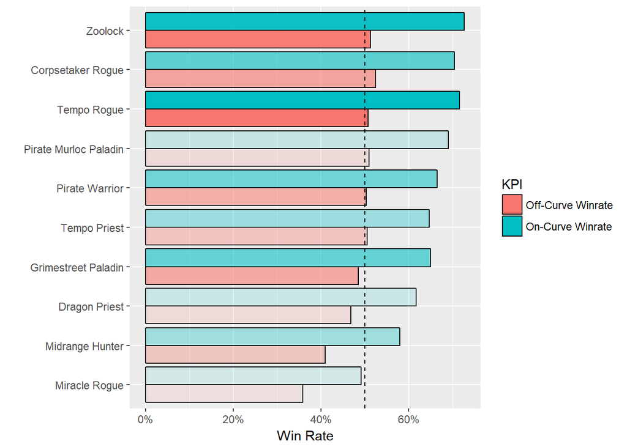

**Figure 1: Win-Rate by archetype for games where Prince Keleseth was played on curve (turn 2, or turn 1 with coin) vs not played on curve. Only decks within the arcehtype that run Prince Keleseth are included. Only archetypes with >1000 games are retained. Opacity is indicative of the number of games played**

[figure not shown]

The effect of an on-curve Keleseth is relatively consistent across the archetypes (especially the non-priest ones). It turns out that the difference between winning and losing conditional on drawing your Keleseth on curve varies between around 32-42% pretty consistently. Of course, many of the decks that include Keleseth share similar characteristics (aggressive style minion based tempo decks) and even a reasonable cross over in card inclusions (Pirates especially). Similarly, not having a 2-drop on turn-2 has fairly similar consequences across the archetypes.

With this in mind, but within that bandwidth, its the highest swing archetypes are actually the most competitive and popular on ladder, and its the on-curve win-rates that tend to separate them in terms of overall win-rate. For example, Tempo Rogue ( [Teir 1](https://hsreplay.net/meta/)) and Pirate Warrior ( [Teir 2](https://hsreplay.net/meta/)) both have near 50% WR in the case that Keleseth isn’t played on curve, but in the case that it is, Tempo Rouge gets a 41% boost compared to 32% for Pirate Warrior.

So turns it out Trumps “Darkest Timeline” was scarily accurate, to paraphrase:

> “Prince Keleseth is run in a deck that win usually 50% of the time… And you play him on turn 2 and win lets say 75% of the time… The deck becomes good and its soley becausea you played Keleseth on 2… Even though it will only happen about 25% of the time… the 25% of the time you win 75% of the time makes the deck good.”

This prediction is pretty much bang-on, even down to the win-rates (especially for Zoolock which was referenced). Blizzard has made it clear they like for every game to feel different, and high-roll mechanics can help that cause. In reality, Keleseth has has the opposite effect due to its sheer amount of play and its presence across multiple top tier decks.